# Penguins R Data

# Introduction

The palmer penguins are a set of penguins inhabiting an Antarctic Penninsula called the Palmer Archepelago. The penguins were wild and inhabited the islands near Palmer Research Base and Anvers Island. The data set defines bill length, bill depth, flipper length, weight, sex, and the location they were found at of 3 species of penguins.

I took this from AI because it just would not work at all to try and find the data set. Like at all.

# Exploratory analysis

This is a large file with lots of data, so we must define the amount of data there actually is.

```r
nrow(penguins)
```

```
## [1] 344
```

```r
ncol(penguins)
```

```
## [1] 8
```

```r
#there are 344 penguins that were surveyed in this data set. This means there are 344 data rows.
#there are 8 data columns, which means we have eight sets of data for each penguin to use.
```

The following displays how many males and females there are in the data set. Some penguins were not sexed. These will be excluded from this data set.

```r
# We will put the males, females, and NA penguins into seprate data packages.
pmale <- penguins[which(penguins$sex == "male") ,]
pfemale <- penguins[grep("female",penguins$sex) ,]
pSexNA <- penguins[is.na (penguins$sex) ,]

#the which function gives an exact match when using ==, and it kept counting all the penguins as male.
#in the dataframe, the sexes for 11 penguins were not entered, so you cannot count it normally.
#so we have to use is.na
#We will count the amount in each.

nrow(pmale)
```

```
## [1] 168
```

```r
nrow(pfemale)
```

```
## [1] 165
```

```r
nrow(pSexNA)
```

```
## [1] 11
```

So, there are 168 male penguins, 165 females, and 11 which were not sexed. The sexes of the penguins are split pretty evenly, so they are represented well, however the NA sexes for some of them can make it difficult to use.

The following displays how many of each penguin there are on the islands.

```r
pAdel <- penguins[grep("Adelie",penguins$species) ,]
pChin <- penguins[grep("Chinstrap",penguins$species) ,]
pGen <- penguins[grep("Gentoo",penguins$species) ,]

#This saves each species into a separate data container

nrow(pAdel)
```

```
## [1] 152
```

```r
nrow(pChin)
```

```
## [1] 68
```

```r
nrow(pGen)
```

```
## [1] 124
```

We have 152 Adelie penguins, 68 Chinstrap penguins, and 124 Gentoo penguins.

The following displays how many penguins were on each island.

```r
iBis <- penguins[grep("Biscoe",penguins$island) ,]
iDream <- penguins[grep("Dream",penguins$island) ,]
iTorg <- penguins[grep("Torgersen",penguins$island) ,]

#this saves the amount of penguins on each island to a separate data file.

nrow(iBis)
```

```
## [1] 168
```

```r
nrow(iDream)
```

```
## [1] 124
```

```r
nrow(iTorg)
```

```
## [1] 52
```

There were 168 penguins on Biscoe Island, 124 on Dream Island, and 52 on Torgersen Island.

# Figures

The following figures represent the characterisitcs that destinguish the sexes of each penguin which is size, and the species on each island. Figure 1 is a jitter plot.

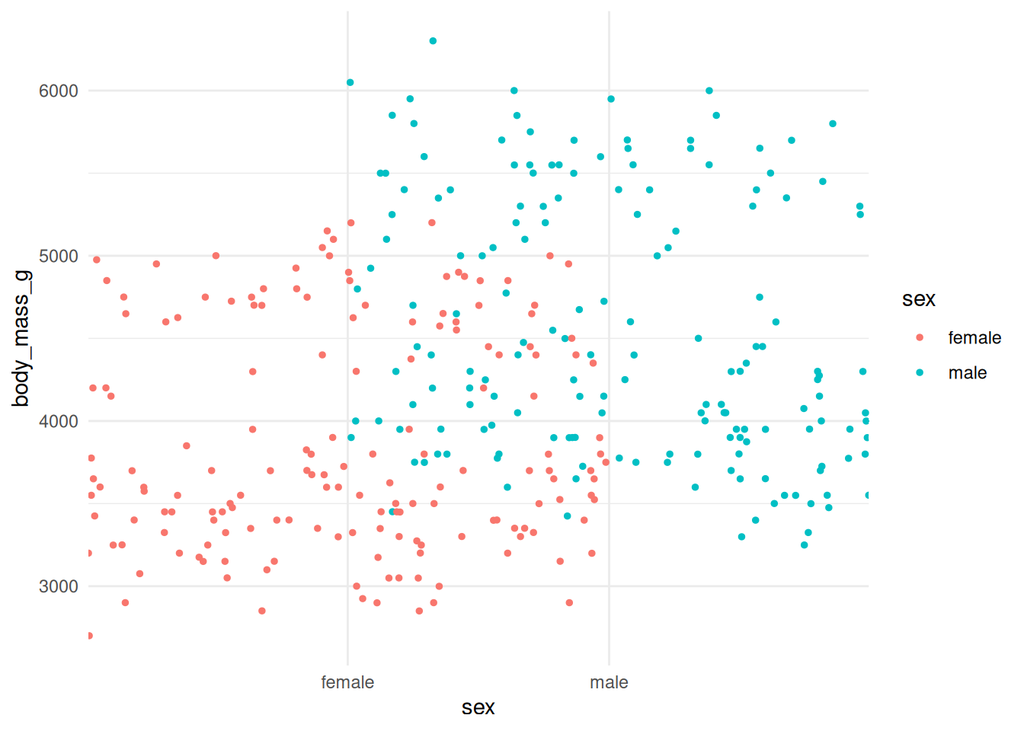

```r
pSexes <- rbind(pmale, pfemale)
ggplot(pSexes, aes(x = sex, y = body_mass_g, color = sex)) +
geom_jitter(width = 1, height = 1, alpha = 1.0, size = 1) + theme_minimal()
```

Figure 1. Penguin sexes vs body mass in grams. Males seem to fall into the larger end of the dataset, while females seem to be smaller. This suggests sexual dimorphism, but all species are plotted together.

Figure 2 is counting plot, and represents the amount of species on each island.

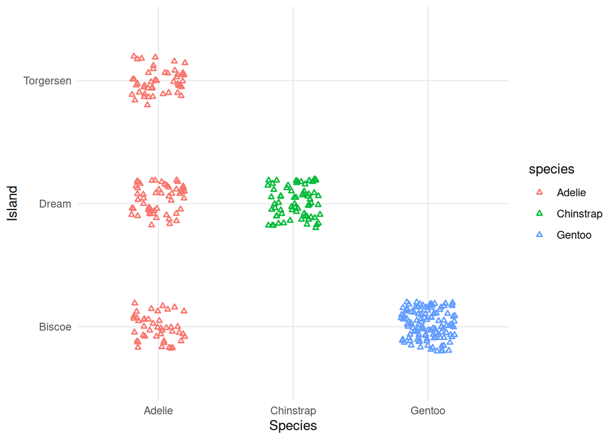

```r
plot_data <- bind_rows(pmale, pfemale)
ggplot(plot_data, aes(x = species, y = island, color = species)) +
geom_point( position = position_jitter(width = 0.2, height = 0.2), shape = 2, size = 1, stroke = 0.8) + labs(x = "Species", y = "Island",) + theme_minimal()
```

The graph suggests that Chinstrap and Gentoo penguins are endemic in this archepelago to Dream and Biscoe island respectively.